# Bivariate OLS Regression

February 12, 2018

## Overview

- Modeling relationships
- Challenges for statistical modeling
- Analytical approaches
- The OLS model
- Characteristics of OLS estimates
- OLS diagnostics: Part 1
- Summary

## Modeling relationships

[figure not shown]

## Modeling relationships

## Modeling relationships

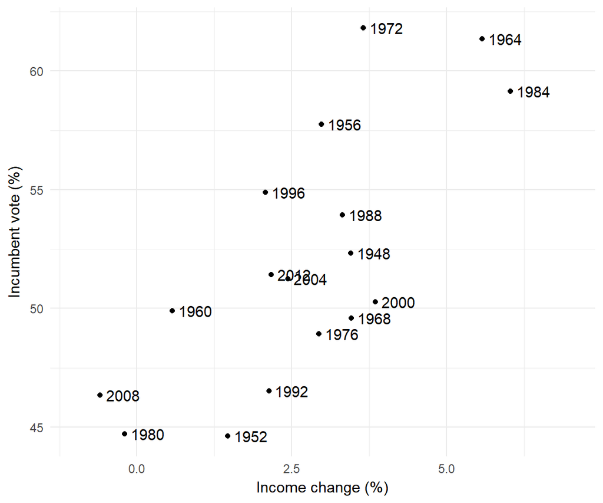

## Modeling relationships

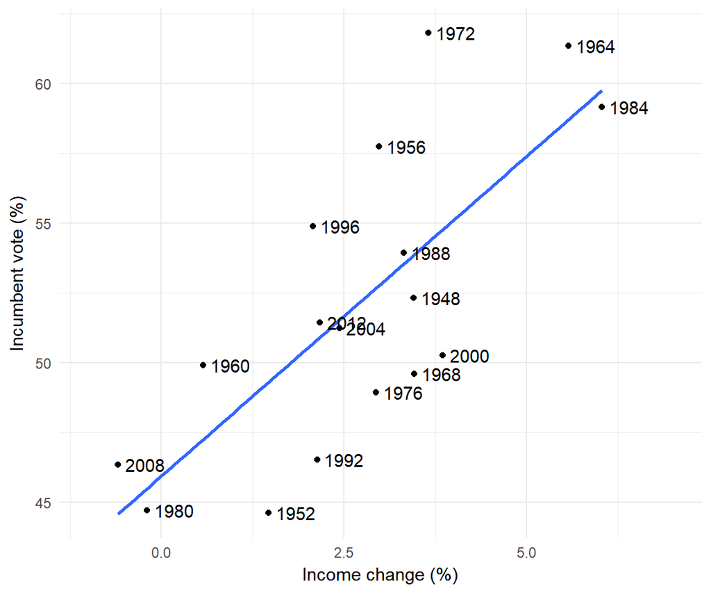

## Challenges

- Two core statistical challenges
  - Randomness - a challenge for inference
  - Endogeneity - a challenge for identification
- Randomness: all statistical estimates are random
  - Sampling variation
  - Modeled variation
- Endogeneity: changes in IV related to other factors affecting DV
- Exogeneity: changes in IV *unrelated* to other factors affecting DV

## Modeling relationships

[figure not shown]

## Analytical approaches

- Experiments
  - Lab, survey, field
  - Gold standard
  - Not always possible
- Observational studies
  - Standard datasets
- Natural experiments
  - Identify situation where values of IV are random, or at least exogenous
- All strive for validity
  - Internal validity: inference (model) = *unbiased*
    - Endogeneity causes bias
  - External validity: inference applies generally
    - To unsampled data
    - To the world
    - a.k.a. *generalizability*

## Ordinary least squares regression model

\[y = mx + b\]

## Ordinary least squares regression model

\[y_{i} = \beta_{0} + \beta_{1}x_{i}\]

## Ordinary least squares regression model

\[y_{i} = \beta_{0} + \beta_{1}x_{i} + \epsilon_{i}\]

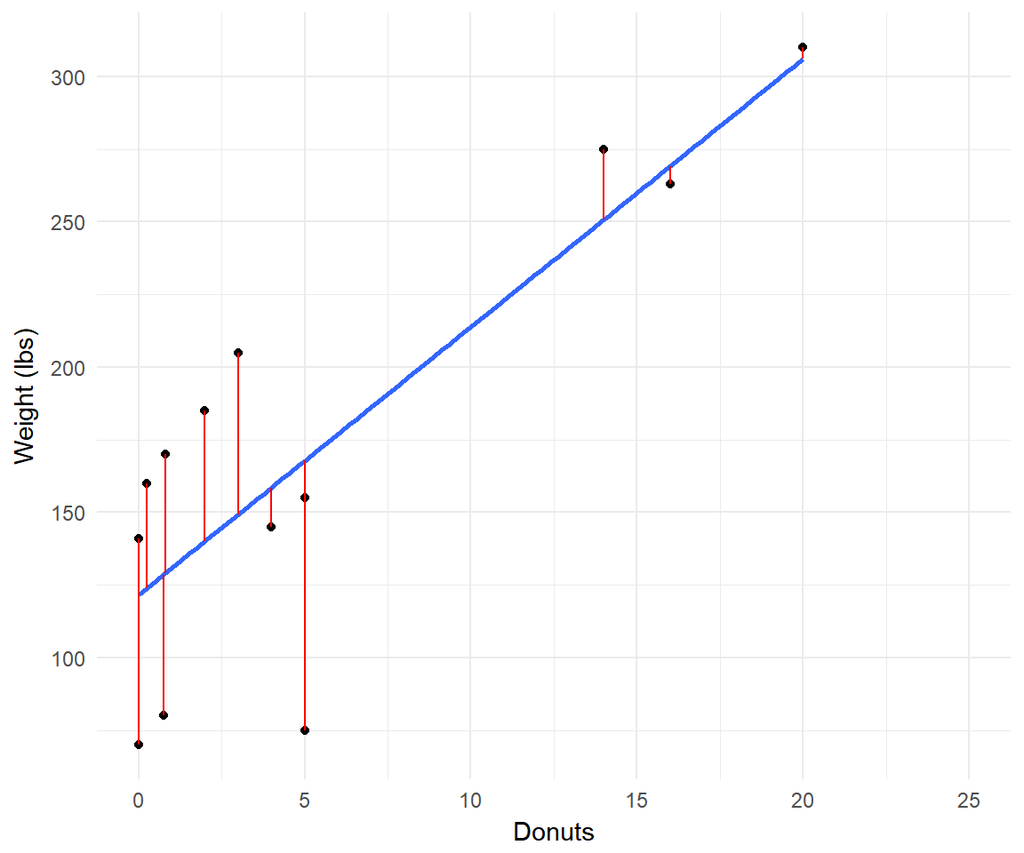

## Ordinary least squares regression model

\[y_{i} = \beta_{0} + \beta_{1}x_{i} + \epsilon_{i}\]

\(x_{i} = \) the independent variable (IV)

\(y_{i} = \) the dependent variable (DV)

\(\beta_{0} = \) the intercept *or* the constant; indicates where the regression line crosses the y-axis; it is the expected value of *y* when *x = 0*

\(\beta_{1} = \) the slope; indicates how much change in *y* is expected if *x* increases by one unit; almost always more interesting than \(\beta_{0} \)

\(\epsilon_{i} = \) the error *or* the residual; portion of *y* not explained by *x*

## Ordinary least squares regression model

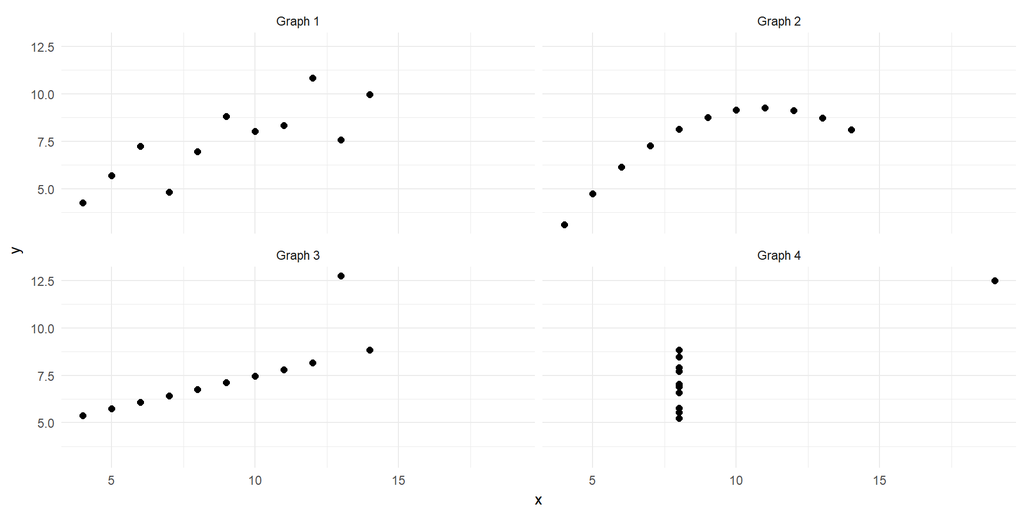

## OLS model: Income growth & incumbency

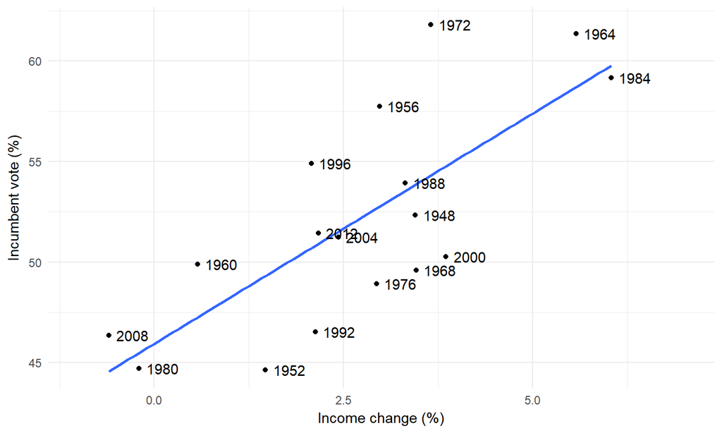

## OLS model: Income growth & incumbency

\(\widehat\beta_{1} = 2.29\)

```
##
## Call:
## lm(formula = vote ~ rdi4, data = r)
##
## Residuals:
##     Min      1Q  Median      3Q     Max
## -4.6842 -3.7406 -0.2731  2.6357  7.5002
##
## Coefficients:
##             Estimate Std. Error t value Pr(>|t|)
## (Intercept)  45.9385     1.6919  27.152 3.62e-14 ***
## rdi4          2.2906     0.5342   4.288 0.000648 ***
## ---
## Signif. codes:  0 '***' 0.001 '**' 0.01 '*' 0.05 '.' 0.1 ' ' 1
##
## Residual standard error: 3.765 on 15 degrees of freedom
## Multiple R-squared:  0.5507, Adjusted R-squared:  0.5207
## F-statistic: 18.38 on 1 and 15 DF,  p-value: 0.0006477
```

## OLS model: distribution of estimates

\(\widehat\beta_{1} = 2.29\) (from income/vote model)

- \(\widehat\beta_{1} = random\)
  - \(\widehat{Y}_{i} \) is part of the equation for \(\widehat\beta_{1}\)
  - \(\widehat{Y}_{i} \) depends on \(\epsilon_{i} \), which is random

Randomness occurs in two ways: sampling & modeled variation

- Sampling variation results from the randomness of the observations selected into the sample from the population
- Modeled variation results from the inherent randomness in the data generated even when data is measured for an entire population

## OLS model: distribution of estimates

A *probability distribution* is a graph or formula that gives the probability of each value of a random variable

The distribution of \(\widehat\beta_{1} \) will be normally distributed if either:

- Sample size is large (Central Limit Theorem)
- Errors \(\epsilon \) are normally distributed
- CLT: the mean of a sufficient number of independent draws from any distribution will be normally distributed.

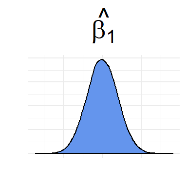

## OLS model: bias in estimates

- A **biased** coefficient estimate will systematically be higher or lower than the true value
- An estimator is **unbiased** if the *expected value* equals the true value
- **Bias** is almost always due to endogeneity

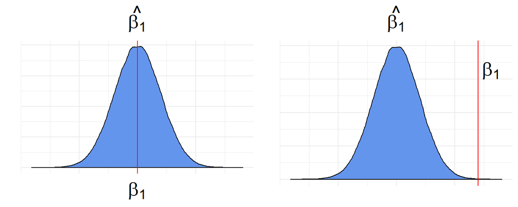

## OLS model: precision of estimates

\[ Var(\widehat\beta_{1}) = \frac{\sigma^2}{N * var(X)} \]

\(\sigma^2 = variance~ of~ the~ regression\) (More in a bit)

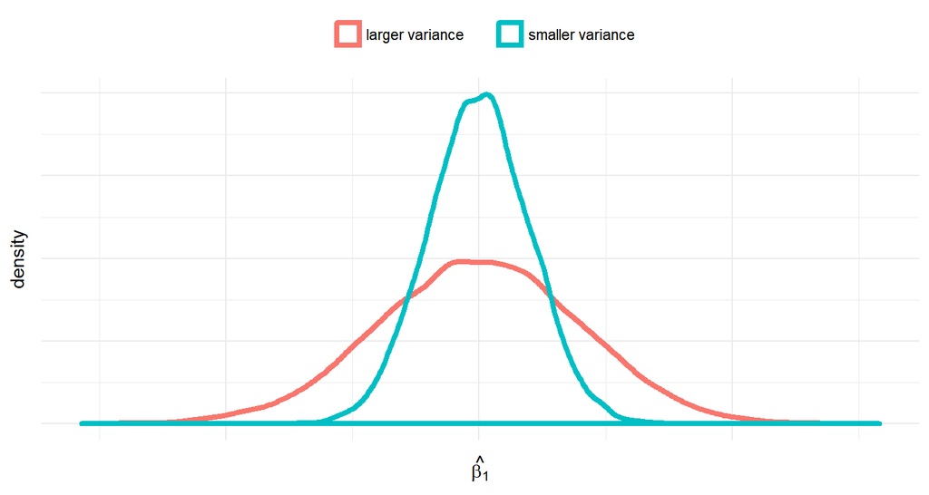

## OLS model: precision of estimates

### As N increases, \(var(\widehat\beta_{1})\) decreases

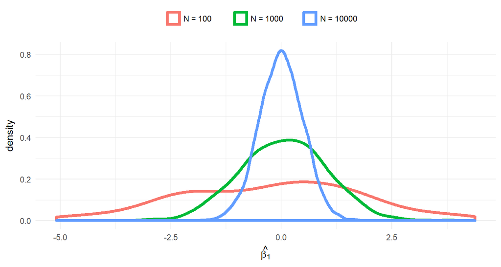

## OLS model: precision of estimates

### Estimators are *consistent* if \(\widehat\beta_{1}\) converges to \(\beta_{1}\)

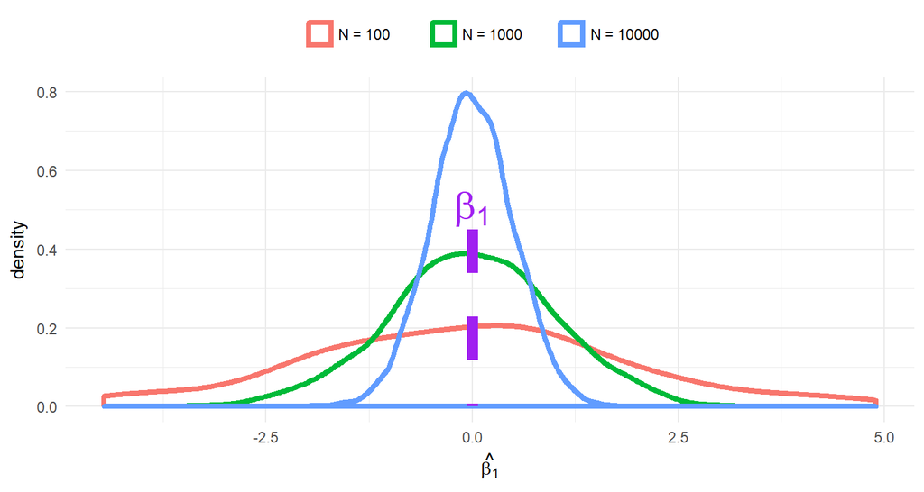

## OLS model: precision of estimates

### Probability limit (plim)

- value to which an estimator converges as sample size gets very large

### Consistency

- estimators are consistent if the *plim* converges to the *TRUE* value
- if the exogeneity requirement is met, estimators are consistent

## OLS model: goodness of fit (GOF)

Remember that \(Var(\widehat\beta_{1}) = \frac{\sigma^2}{N * var(X)}\)

\(\sigma^2 = variance~ of~ the~ regression\) & measures how well the model explains the variation in *Y*

```
##
## Call:
## lm(formula = vote ~ rdi4, data = r)
##
## Residuals:
##     Min      1Q  Median      3Q     Max
## -4.6842 -3.7406 -0.2731  2.6357  7.5002
##
## Coefficients:
##             Estimate Std. Error t value Pr(>|t|)
## (Intercept)  45.9385     1.6919  27.152 3.62e-14 ***
## rdi4          2.2906     0.5342   4.288 0.000648 ***
## ---
## Signif. codes:  0 '***' 0.001 '**' 0.01 '*' 0.05 '.' 0.1 ' ' 1
##
## Residual standard error: 3.765 on 15 degrees of freedom
## Multiple R-squared:  0.5507, Adjusted R-squared:  0.5207
## F-statistic: 18.38 on 1 and 15 DF,  p-value: 0.0006477
```

## OLS model: goodness of fit (GOF)

\(R^2 = \) very popular measure of goodness of fit

- the square of the correlation between the observed \(Y_{i}\) and predicted \(\widehat{Y_{i}}\) values
- measures the *linearity* between \(X_{i}\) & \(Y_{i}\)

```
##
## Call:
## lm(formula = vote ~ rdi4, data = r)
##
## Residuals:
##     Min      1Q  Median      3Q     Max
## -4.6842 -3.7406 -0.2731  2.6357  7.5002
##
## Coefficients:
##             Estimate Std. Error t value Pr(>|t|)
## (Intercept)  45.9385     1.6919  27.152 3.62e-14 ***
## rdi4          2.2906     0.5342   4.288 0.000648 ***
## ---
## Signif. codes:  0 '***' 0.001 '**' 0.01 '*' 0.05 '.' 0.1 ' ' 1
##
## Residual standard error: 3.765 on 15 degrees of freedom
## Multiple R-squared:  0.5507, Adjusted R-squared:  0.5207
## F-statistic: 18.38 on 1 and 15 DF,  p-value: 0.0006477
```

## OLS model: goodness of fit (GOF)

### Look at the data

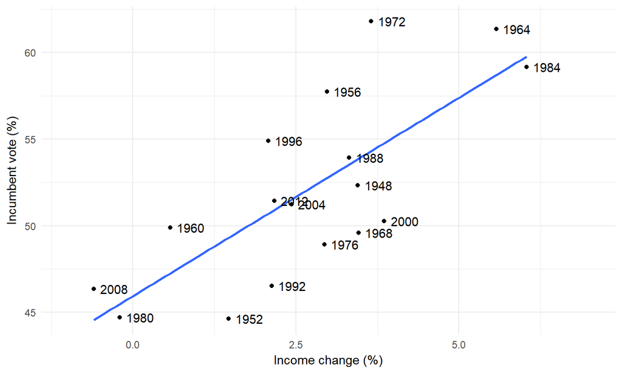

## OLS diagnostics

Homoskedasticity: good

- Errors (residuals) from regression observations all have constant variance
  - No discernible patterns when plotted against fitted values

Heteroskedasticity: bad

- Errors (residuals) from regression observations DO NOT have constant variance
  - Discernible patterns when plotted against fitted values
  - Generally, errors are larger at one end of fitted values than the other

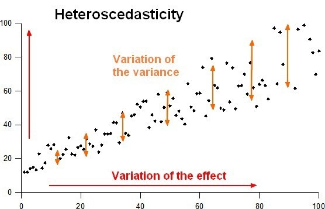

Another example: scale v. state fair weight guesser (p. 68 Bailey)

## OLS diagnostics

Our model

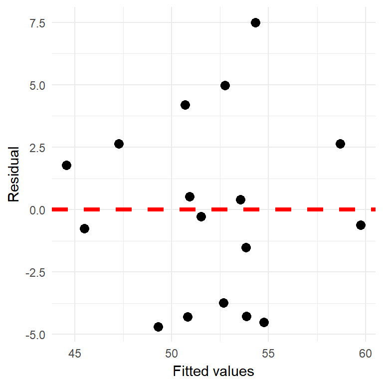

## OLS diagnostics

Impacts of heteroskedasticity

- Does NOT *BIAS* estimates
- However, the variance of estimates might be off (usually too low)

How to fix

- Use a different formula for calculating variance of estimates
- Heteroskedasticity-consistent errors (easy with software)

More formal tests for heteroskedasticity…stay tuned

## OLS diagnostics

Errors uncorrelated with each other: No *autocorrelation*.

- Normally applicable in two situations:
  - Data are clustered in some way
  - Data are time series

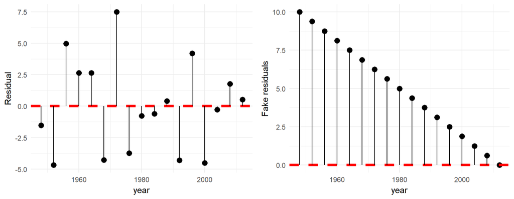

## OLS diagnostics

Impacts of autocorrelation

- Does NOT *BIAS* estimates
- However, the variance of estimates might be off (usually too low)

How to fix

- Use a different formula for calculating variance of estimates
- Autocorrelation-consistent errors (easy with software)

More formal tests for autocorrelation…stay tuned

## OLS diagnostics

Outliers & influential observations

- *Outlier*: an observation that is very different from all the others
- *Influential observation*: a single observation that has substantial impact on model estimates

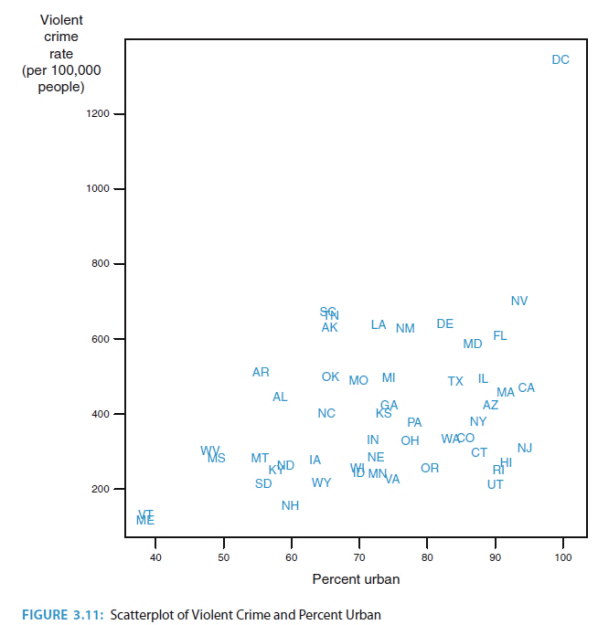

## OLS diagnostics

Outliers & influential observations

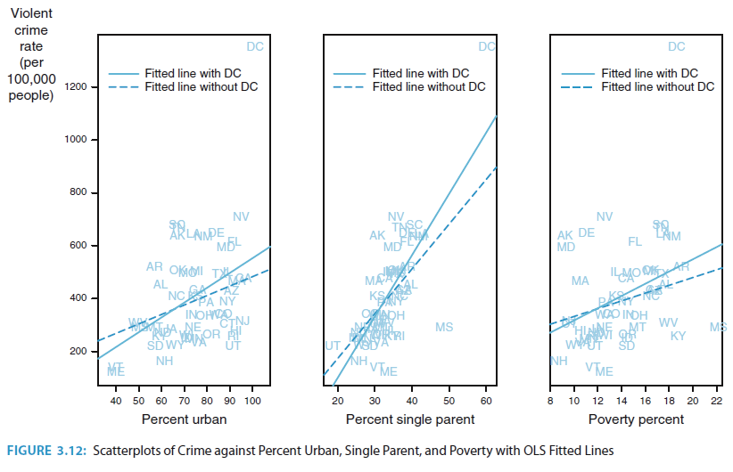

## OLS diagnostics

Outliers & influential observations

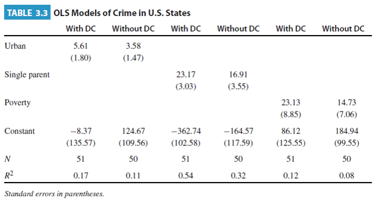

## OLS diagnostics

Outliers & influential observations:

- Can be especially troublesome in smaller samples
- Can exert undue influence over coefficient estimates

How to fix

- Diagnose through plots & comparison
- Inform readers of the issue
- Follow-up: find out more about why the observation is unique
- Report results with & without observation & compare
- Justify including or excluding the observation

*Slightly* more formal tests for influence…stay tuned

## Summary

- Know your data (look at it)
- Be aware of the potential for endogeneity & carefully construct models
- Examine precision in estimates & overall model fit (GOF)
- Perform regression diagnostics on all models